# Data_Visualization_Part1

## Data Visualization

### Wrangling Process

In the analysis below we explore, clean where necessary our dataset so as to communicate using plot and graph our finding and for better understanding our analysis.

The dataset set below is the includes information about individual rides made in a bike-sharing system

```python
# importing all packages
import numpy as np
import pandas as pd
import matplotlib.pyplot as plt
import seaborn as sb

%matplotlib inline
```

```python
# load and viewing in the dataset into a pandas dataframe
trip = pd.read_csv('201902-fordgobike-tripdata.csv')
trip.head()
```

|  | duration_sec | start_time | end_time | start_station_id | start_station_name | start_station_latitude | start_station_longitude | end_station_id | end_station_name | end_station_latitude | end_station_longitude | bike_id | user_type | member_birth_year | member_gender | bike_share_for_all_trip |
| --- | --- | --- | --- | --- | --- | --- | --- | --- | --- | --- | --- | --- | --- | --- | --- | --- |
| 0 | 52185 | 2019-02-28 17:32:10.1450 | 2019-03-01 08:01:55.9750 | 21.0 | Montgomery St BART Station (Market St at 2nd St) | 37.789625 | -122.400811 | 13.0 | Commercial St at Montgomery St | 37.794231 | -122.402923 | 4902 | Customer | 1984.0 | Male | No |
| 1 | 42521 | 2019-02-28 18:53:21.7890 | 2019-03-01 06:42:03.0560 | 23.0 | The Embarcadero at Steuart St | 37.791464 | -122.391034 | 81.0 | Berry St at 4th St | 37.775880 | -122.393170 | 2535 | Customer | NaN | NaN | No |
| 2 | 61854 | 2019-02-28 12:13:13.2180 | 2019-03-01 05:24:08.1460 | 86.0 | Market St at Dolores St | 37.769305 | -122.426826 | 3.0 | Powell St BART Station (Market St at 4th St) | 37.786375 | -122.404904 | 5905 | Customer | 1972.0 | Male | No |
| 3 | 36490 | 2019-02-28 17:54:26.0100 | 2019-03-01 04:02:36.8420 | 375.0 | Grove St at Masonic Ave | 37.774836 | -122.446546 | 70.0 | Central Ave at Fell St | 37.773311 | -122.444293 | 6638 | Subscriber | 1989.0 | Other | No |
| 4 | 1585 | 2019-02-28 23:54:18.5490 | 2019-03-01 00:20:44.0740 | 7.0 | Frank H Ogawa Plaza | 37.804562 | -122.271738 | 222.0 | 10th Ave at E 15th St | 37.792714 | -122.248780 | 4898 | Subscriber | 1974.0 | Male | Yes |

```python
# Veiwing the data samples and variable with the the general info of our dataset
print(trip.shape)
trip.info()
```

```
(183412, 16)
<class 'pandas.core.frame.DataFrame'>
RangeIndex: 183412 entries, 0 to 183411
Data columns (total 16 columns):
 #   Column                   Non-Null Count   Dtype
---  ------                   --------------   -----
 0   duration_sec             183412 non-null  int64
 1   start_time               183412 non-null  object
 2   end_time                 183412 non-null  object
 3   start_station_id         183215 non-null  float64
 4   start_station_name       183215 non-null  object
 5   start_station_latitude   183412 non-null  float64
 6   start_station_longitude  183412 non-null  float64
 7   end_station_id           183215 non-null  float64
 8   end_station_name         183215 non-null  object
 9   end_station_latitude     183412 non-null  float64
 10  end_station_longitude    183412 non-null  float64
 11  bike_id                  183412 non-null  int64
 12  user_type                183412 non-null  object
 13  member_birth_year        175147 non-null  float64
 14  member_gender            175147 non-null  object
 15  bike_share_for_all_trip  183412 non-null  object
dtypes: float64(7), int64(2), object(7)
memory usage: 22.4+ MB
```

```python
# General statistics of the dataset
trip.describe()
```

|  | duration_sec | start_station_id | start_station_latitude | start_station_longitude | end_station_id | end_station_latitude | end_station_longitude | bike_id | member_birth_year |
| --- | --- | --- | --- | --- | --- | --- | --- | --- | --- |
| count | 183412.000000 | 183215.000000 | 183412.000000 | 183412.000000 | 183215.000000 | 183412.000000 | 183412.000000 | 183412.000000 | 175147.000000 |
| mean | 726.078435 | 138.590427 | 37.771223 | -122.352664 | 136.249123 | 37.771427 | -122.352250 | 4472.906375 | 1984.806437 |
| std | 1794.389780 | 111.778864 | 0.099581 | 0.117097 | 111.515131 | 0.099490 | 0.116673 | 1664.383394 | 10.116689 |
| min | 61.000000 | 3.000000 | 37.317298 | -122.453704 | 3.000000 | 37.317298 | -122.453704 | 11.000000 | 1878.000000 |
| 25% | 325.000000 | 47.000000 | 37.770083 | -122.412408 | 44.000000 | 37.770407 | -122.411726 | 3777.000000 | 1980.000000 |
| 50% | 514.000000 | 104.000000 | 37.780760 | -122.398285 | 100.000000 | 37.781010 | -122.398279 | 4958.000000 | 1987.000000 |
| 75% | 796.000000 | 239.000000 | 37.797280 | -122.286533 | 235.000000 | 37.797320 | -122.288045 | 5502.000000 | 1992.000000 |
| max | 85444.000000 | 398.000000 | 37.880222 | -121.874119 | 398.000000 | 37.880222 | -121.874119 | 6645.000000 | 2001.000000 |

```python
# Converting start_time and end_time to datetime
trip[['start_time','end_time']] = trip[['start_time','end_time']].apply(pd.to_datetime)
```

```python
# Creating new column of Day and Month using the start_time
trip['day'] = trip['start_time'].dt.day_name()
trip['month'] = trip['start_time'].dt.month_name()
trip['hour'] = trip['start_time'].dt.hour
```

```python
# converting user_type and member_gender to category
trip['user_type'] = trip['user_type'].astype('category')
trip['member_gender'] = trip['member_gender'].astype('category')
```

```python
# checking for missing data
trip.isnull().sum()
```

```
duration_sec                  0
start_time                    0
end_time                      0
start_station_id            197
start_station_name          197
start_station_latitude        0
start_station_longitude       0
end_station_id              197
end_station_name            197
end_station_latitude          0
end_station_longitude         0
bike_id                       0
user_type                     0
member_birth_year          8265
member_gender              8265
bike_share_for_all_trip       0
day                           0
month                         0
hour                          0
dtype: int64
```

```python
# Dropping the missing missing values in our dataset
trip = trip.dropna()
```

```python
# Calculating the individuals age and assigning it to a column
trip['age'] = 2019-trip['member_birth_year'].astype('int64')
```

```python
# dropping the member_birth_year
trip.drop('member_birth_year', axis=1, inplace=True)
```

```python
# Checking our dataseet info to confirm our changes
trip.info()
```

```
<class 'pandas.core.frame.DataFrame'>
Int64Index: 174952 entries, 0 to 183411
Data columns (total 19 columns):
 #   Column                   Non-Null Count   Dtype
---  ------                   --------------   -----
 0   duration_sec             174952 non-null  int64
 1   start_time               174952 non-null  datetime64[ns]
 2   end_time                 174952 non-null  datetime64[ns]
 3   start_station_id         174952 non-null  float64
 4   start_station_name       174952 non-null  object
 5   start_station_latitude   174952 non-null  float64
 6   start_station_longitude  174952 non-null  float64
 7   end_station_id           174952 non-null  float64
 8   end_station_name         174952 non-null  object
 9   end_station_latitude     174952 non-null  float64
 10  end_station_longitude    174952 non-null  float64
 11  bike_id                  174952 non-null  int64
 12  user_type                174952 non-null  category
 13  member_gender            174952 non-null  category
 14  bike_share_for_all_trip  174952 non-null  object
 15  day                      174952 non-null  object
 16  month                    174952 non-null  object
 17  hour                     174952 non-null  int64
 18  age                      174952 non-null  int64
dtypes: category(2), datetime64[ns](2), float64(6), int64(4), object(5)
memory usage: 24.4+ MB
```

```python
trip.head()
```

|  | duration_sec | start_time | end_time | start_station_id | start_station_name | start_station_latitude | start_station_longitude | end_station_id | end_station_name | end_station_latitude | end_station_longitude | bike_id | user_type | member_gender | bike_share_for_all_trip | day | month | hour | age |
| --- | --- | --- | --- | --- | --- | --- | --- | --- | --- | --- | --- | --- | --- | --- | --- | --- | --- | --- | --- |
| 0 | 52185 | 2019-02-28 17:32:10.145 | 2019-03-01 08:01:55.975 | 21.0 | Montgomery St BART Station (Market St at 2nd St) | 37.789625 | -122.400811 | 13.0 | Commercial St at Montgomery St | 37.794231 | -122.402923 | 4902 | Customer | Male | No | Thursday | February | 17 | 35 |
| 2 | 61854 | 2019-02-28 12:13:13.218 | 2019-03-01 05:24:08.146 | 86.0 | Market St at Dolores St | 37.769305 | -122.426826 | 3.0 | Powell St BART Station (Market St at 4th St) | 37.786375 | -122.404904 | 5905 | Customer | Male | No | Thursday | February | 12 | 47 |
| 3 | 36490 | 2019-02-28 17:54:26.010 | 2019-03-01 04:02:36.842 | 375.0 | Grove St at Masonic Ave | 37.774836 | -122.446546 | 70.0 | Central Ave at Fell St | 37.773311 | -122.444293 | 6638 | Subscriber | Other | No | Thursday | February | 17 | 30 |
| 4 | 1585 | 2019-02-28 23:54:18.549 | 2019-03-01 00:20:44.074 | 7.0 | Frank H Ogawa Plaza | 37.804562 | -122.271738 | 222.0 | 10th Ave at E 15th St | 37.792714 | -122.248780 | 4898 | Subscriber | Male | Yes | Thursday | February | 23 | 45 |
| 5 | 1793 | 2019-02-28 23:49:58.632 | 2019-03-01 00:19:51.760 | 93.0 | 4th St at Mission Bay Blvd S | 37.770407 | -122.391198 | 323.0 | Broadway at Kearny | 37.798014 | -122.405950 | 5200 | Subscriber | Male | No | Thursday | February | 23 | 60 |

### The structure of The Dataset

The dataset consist of 183412 user samples and 16 features (start_time, end_time, start_station_id, start_station_name, start_station_latitude, start_station_longitude, end_station_id, end_station_name, end_station_latitude, end_station_longitude, bike_id, user_type, member_gender, bike_share_for_all_trip) with different datatypes. Some of these datatypes were changed during our wrangling process for proper data analysis.

The dataset consists of missing values which were dropped, the age of individual users were calculate with the year in which the data were collected and the member_birth_year was dropped since it wasn't needed anymore during the wrangling process. From the start_time we were able to create the day, hour and month column.

### The Main Feature of Interest in Our Dataset

In our dataset we mostly interested in the duration in sec the user uses a bike or rides and the factors the affect this time

### Features I Think That Would Necessarily Support My Investigations

I look at for the start_time and the end_time, i expect them to be one of the major influence in the duration of a trip since we have extracted the day, month and hour which can be of help to our investigation. Inspite of that the bike_share_for_all_trip, user_type, gender and age can also be of influence. However we might looking the start_station and end_station as different station can have different topography might also affect the duration of the user, traffic situation in different station can elongate the duration too.

### Univariate Exploration

In the exploration of our data we will start by looking at the distribution of the Feature of Interest that is the duration_sec

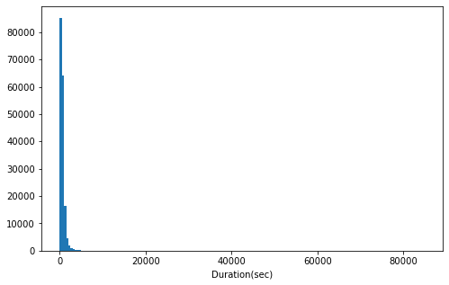

```python
# Plotting a standard scale plot
bins = np.arange(0, trip['duration_sec'].max()+500, 500)

plt.figure(figsize=[8, 5])
plt.hist(data = trip, x = 'duration_sec', bins = bins)
plt.xlabel('Duration(sec)')
plt.show()
```

The distribution shows that there is a longtail, so we will try to put it together using a log scale

```python
# showing the statistics of duration_sec in log
np.log10(trip['duration_sec'].describe())
```

```
count    5.242919
mean     2.847574
std      3.215427
min      1.785330
25%      2.509203
50%      2.707570
75%      2.897077
max      4.927103
Name: duration_sec, dtype: float64
```

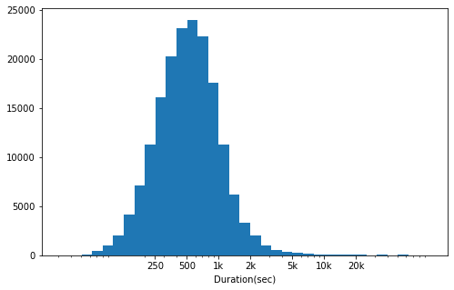

```python
# Showing the distribution in a log scale
bins = 10 ** np.arange(1.5, np.log10(trip['duration_sec'].max())+0.1, 0.1)

plt.figure(figsize=[8, 5])
plt.hist(data = trip, x = 'duration_sec', bins = bins)
plt.xscale('log')
plt.xticks([250, 500, 1e3, 2e3, 5e3, 1e4, 2e4], [250, 500, '1k', '2k', '5k', '10k', '20k'])
plt.xlabel('Duration(sec)')
plt.show()
```

Since the distribution has a long tail when plotting on a standard scale, we have to plot the duration_sec using a log-scale which looks as a unimodal, with more number of trips covered below 2000sec and having it's peak around 600sec then starts to fall around 800sec to 20000sec

We will look at other features which can influence the duration_sec like distribution of the user_type,gender and age, then the start and end station_id

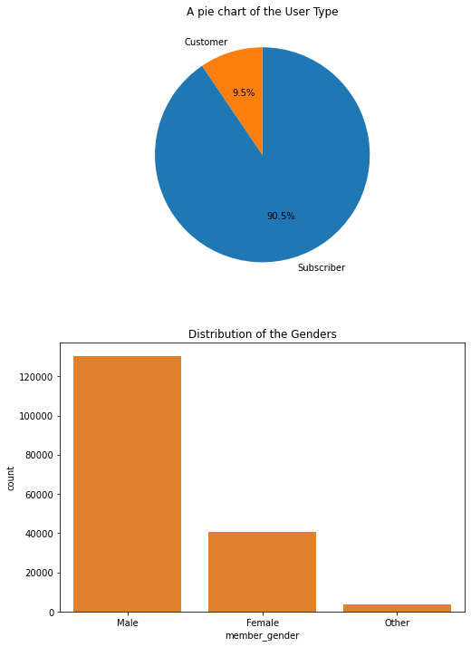

```python
# Plotting the user_type on a pie chart
plt.figure(figsize=[8,12])
sort_count = trip['user_type'].value_counts()
a_color = sb.color_palette()[0]
plt.subplot(2,1,1)
plt.pie(sort_count, labels= sort_count.index, startangle=90, counterclock=False, autopct='%.1f%%')
plt.title('A pie chart of the User Type')

# plotting gender on a bar chart
freq = trip['member_gender'].value_counts()
gen_order = freq.index
b_color = sb.color_palette()[1]
plt.subplot(2,1,2)
sb.countplot(data=trip, x='member_gender', color=b_color, order=gen_order)
plt.title('Distribution of the Genders');
```

From the pie chart of the user_type above we could see clearly that their is higher percentage of subscribers of about to 90.5% in comparison with 9.5% of customers users. The second plot is a bar chart of member_gender, we observed as seen more number of males to compare with females and others in our dataset.

```python
# Statistics of the log of age
np.log10(trip['age'].describe())
```

```
count    5.242919
mean     1.533986
std      1.005126
min      1.255273
25%      1.431364
50%      1.505150
75%      1.591065
max      2.149219
Name: age, dtype: float64
```

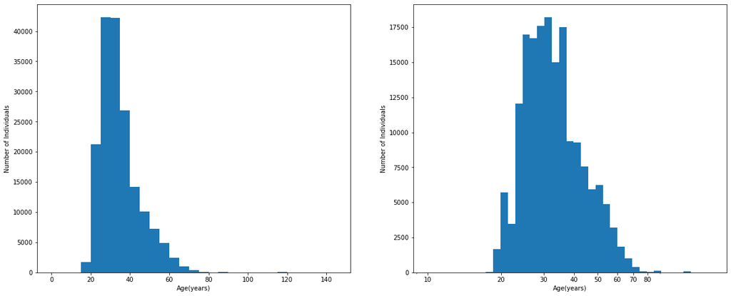

```python
# Plotting the distribution of age on a standard scale and a log scale
plt.figure(figsize=[20, 8])
plt.subplot(1,2,1)
bins = np.arange(0, trip['age'].max()+5, 5)
plt.hist(data = trip, x = 'age', bins = bins)
plt.xlabel('Age(years)')
plt.ylabel('Number of Individuals')

plt.subplot(1,2,2)
bins = 10 ** np.arange(1.0, np.log10(trip['age'].max())+0.03, 0.03)
plt.hist(data = trip, x = 'age', bins = bins)
plt.xscale('log')
plt.xticks([10, 20, 30, 40, 50, 60, 70, 80], [10, 20, 30, 40, 50, 60, 70, 80])
plt.xlabel('Age(years)')
plt.ylabel('Number of Individuals')
plt.show();
```

From the plot we can see that the age distribution is focused more between the age of 20 to 40years that is to say that people in this range participated more in our dataset

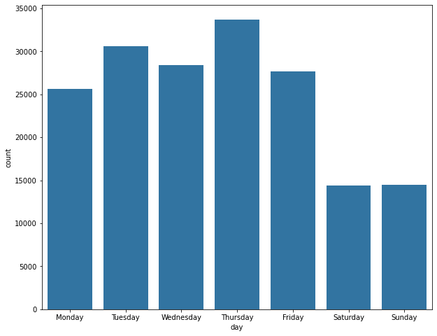

```python
days = ['Monday', 'Tuesday', 'Wednesday', 'Thursday', 'Friday', 'Saturday', 'Sunday']
base_color = sb.color_palette()[0]
plt.figure(figsize=(10,8))
sb.countplot(data=trip, x='day', order=days, color=base_color);
```

From the plot of the distribution of days shown we can tell that users involves more on trips on Thursdays and other weekdays than on saturdays and sundays which are weekends

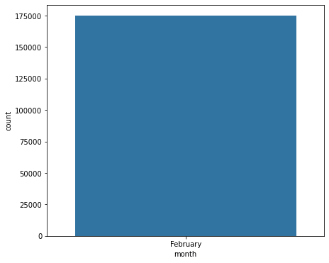

```python
plt.figure(figsize= (7,6))
sb.countplot(data=trip, x='month');
```

This shows that all trips in our dataset occured in february

```python
trip['month'].value_counts()
```

```
February    174952
Name: month, dtype: int64
```

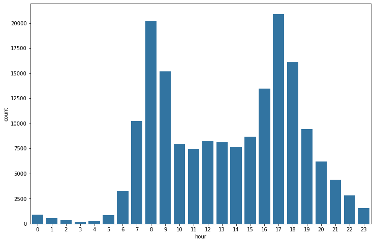

```python
hours = np.arange(0,24,1)
base_color = sb.color_palette()[0]
plt.figure(figsize=(12,8))
sb.countplot(data=trip, x='hour', order=hours, color=base_color);
```

We look at the plot of the time or hours in a day, we see that most users make more trips at the hour mark of 8am and 5pm. This can be attributed with opening and closing work time.

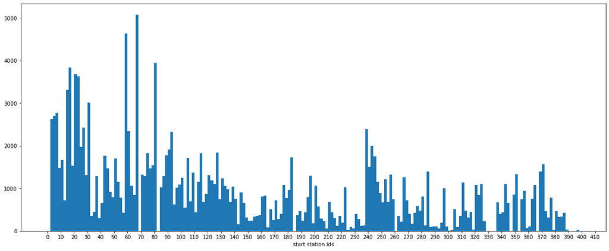

```python
# Viewing the start station distribution using the start station id's
tick_prop = np.arange(0,420,10)
bins = np.arange(0,trip['start_station_id'].max()+2,2)
plt.figure(figsize=(20,8))
plt.hist(data=trip, x= 'start_station_id', bins=bins)
plt.xlabel('start station ids')
plt.xticks(tick_prop)
plt.show();
```

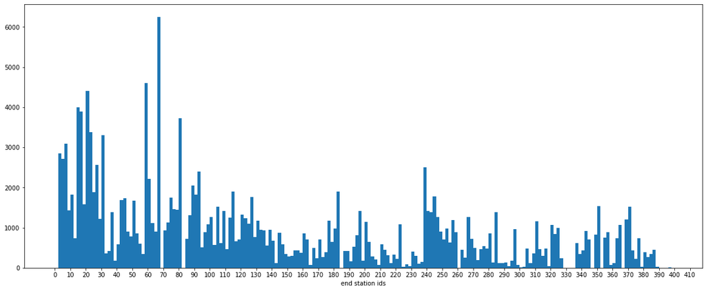

```python
# Viewing the end station distribution using the end station id's
tick_prop = np.arange(0,420,10)
bins = np.arange(0,trip['end_station_id'].max()+2,2)
plt.figure(figsize=(20,8))
plt.hist(data=trip, x= 'end_station_id', bins=bins)
plt.xlabel('end station ids')
plt.xticks(tick_prop)
plt.show();
```

From the distribution of the start and end station using the id's. As depicts in the histogram above, both distribution appears the same which signifies having the same number frequency of occurance at both the start and end station.

### The Distribution(s) of Your Variable(s) of Interest, Unusual Points and Transformations Performed.

The distribution of duration_sec which is the variable of interest on a standard scale show a longtail which can be interpreted as the values being choked at a point, In order to fix this we try to plot the distribution using a log scale to transform our plot. The log scale shows more number of trips covered below 2000sec and having it's peak around 600sec then starts to fall around 800sec to 20000sec

### Of the features investigated, operations performed on the data to tidy, adjust, or change the form of the data and reason doing so.

Before the investigation of the features i think would necessarily influence the trip duration, i did so data wrangling which involves exploring, cleaning and tidying the data, so as to avoid unusual behaviour of the distribution and made by outliers. All null and missing data in the dataset were dropped and change of datatypes were made in some variables.

### Bivariate Exploration

Here we will view the relationship of one variable to another.

Let's start by viewing the coorelation between the duration_sec and age

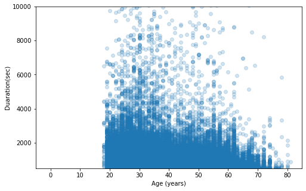

```python
plt.figure(figsize=[8,5])
plt.scatter(data=trip, x='age', y='duration_sec', alpha=0.2 )
plt.axis([-5, 85, 500, 10000])
plt.xlabel('Age (years)')
plt.ylabel('Duaration(sec)')
plt.show()
```

The scatter plot of age on x-axis and duration on y-axis shows that more people between the age of 20 and 40 has higher duration of trip.

Let's view this in a heatmap for clearer understanding

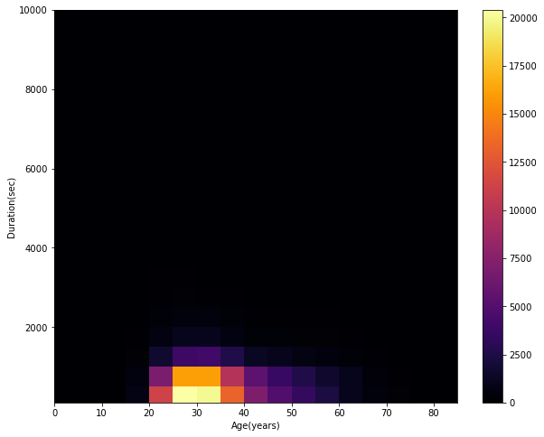

```python
# heatmap of duration and age
bins_x = np.arange(0, trip['age'].max()+5, 5)
bins_y = np.arange(0, trip['duration_sec'].max()+500, 500)
plt.figure(figsize=[10,8])
plt.hist2d(data=trip, x='age', y='duration_sec', cmap='inferno', bins =[bins_x,bins_y])
plt.axis([0, 85, 100, 10000])
plt.colorbar()
plt.xlabel('Age(years)')
plt.ylabel('Duration(sec)')
plt.show()
```

Let's look at how the user_type affects the duration, then we can also investigate on the gender too

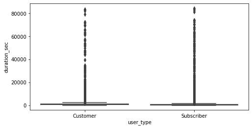

```python
# Plotting a boxplot of user_type on duration
plt.figure(figsize=[8,4])
base_color = sb.color_palette()[0]
sb.boxplot(data=trip, x='user_type', y='duration_sec', color=base_color);
```

Let's rescale so we can see our values

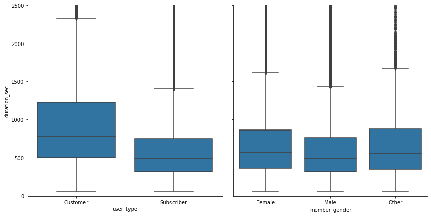

```python
# Defining a function for plotting a boxplot
def boxgrid(x, y, **kwargs):
    base_color = sb.color_palette()[0]
    sb.boxplot(x,y, color=base_color)

# plotting a boxplot of user_type and member_gender on duration
plt.figure(figsize= (5,5))
g = sb.PairGrid(data=trip, y_vars='duration_sec', x_vars=['user_type', 'member_gender'], height=6)
g.map(boxgrid)
plt.ylim([-5,2500])
plt.show();
```

In the first box plot of the user_type we observed that higher percentage of customers make longer trip in comparison with the subscribers. The second boxplot is the plot of member_gender against the duration_sec, we can confirm that despite the percentage of male being the most users as seen in the distribution of the member_gender in the univariate exploration, when compare with the duration we see that we have more percentage of female and other riding longer than the male.

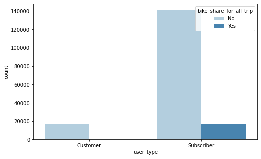

```python
# Plotting a cluster barchart of user_type and bike_share_for_all_trip
plt.figure(figsize=(8,5))
sb.countplot(data=trip, x='user_type', hue='bike_share_for_all_trip', palette='Blues');
```

We can see from the plot that bike share is only applicable to subscribers.

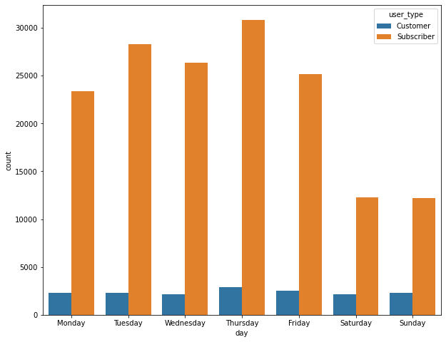

```python
# Plotting a cluster bar chart of the day and the usertype
days = ['Monday', 'Tuesday', 'Wednesday', 'Thursday', 'Friday', 'Saturday', 'Sunday']
plt.figure(figsize=(10,8))
sb.countplot(data=trip, x='day', hue='user_type', order=days);
```

From the cluster bar chart above the graph behaves normal, the customer and subscribers have both peak on Thursdays.

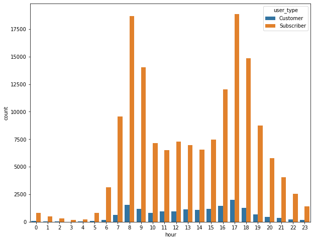

```python
# # Plotting a cluster bar chart of the hour and the usertype
hours = np.arange(0,24,1)
plt.figure(figsize=(10,8))
sb.countplot(data=trip, x='hour', hue='user_type', order=hours);
```

Here in the cluster barchart of hour and usertype the customer appears to ride more during working hours.

### Multivariate Exploration

Here we will look the relation between more than two variables in our dataset.

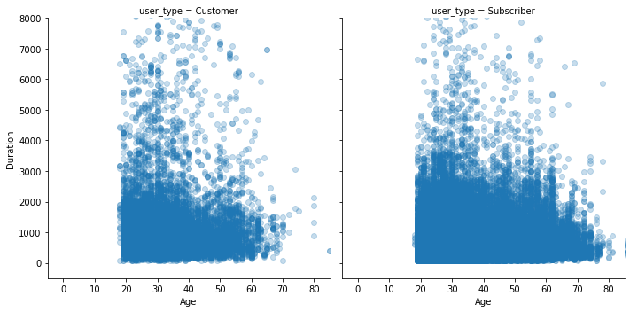

```python
g = sb.FacetGrid(data = trip, col = 'user_type', col_wrap = 2, height = 5,
                 xlim = [-5, 85], ylim = [-500, 8000])
g.map(plt.scatter, 'age', 'duration_sec', alpha=0.25)
g.set_xlabels('Age')
g.set_ylabels('Duration')

plt.show()
```

In the both scatter plot, they are similar with the scatter plot in the bivariate section of age against duration which showed that longer duration are taken by younger people ranging from 20 to 40years. The Customers user_type says the same but the Subscribers has showed an extention in age to 60years

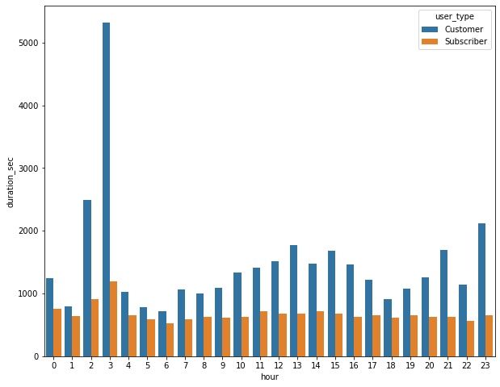

```python
# Plotting a cluster barplot for hour, duration and user type
plt.figure(figsize=(10,8))
sb.barplot(data=trip, x='hour', y='duration_sec', hue='user_type',ci=None, order=hours);
```

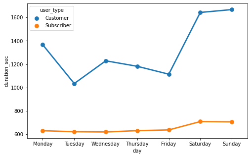

```python
# Plotting a pointplot for day, duration and user type
days = ['Monday', 'Tuesday', 'Wednesday', 'Thursday', 'Friday', 'Saturday', 'Sunday']
plt.figure(figsize=(8,5))
sb.pointplot(data=trip, x='day', y='duration_sec', hue='user_type',ci=None, order=days);
```

From the pointplot, we see the customers spend more duration with most duration during weekends. The subscribers seems to be consistent in their duration with little increase on weekends.

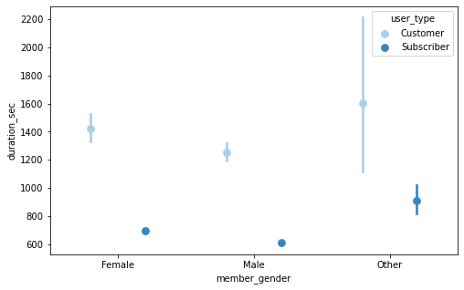

```python
# Plotting a pointplot for member_gender, duration and user type
plt.figure(figsize=(8,5))
ax = sb.pointplot(data=trip, x='member_gender', y='duration_sec', hue='user_type', palette='Blues', linestyles='', dodge = 0.4)
ax.set_yticklabels([],minor = True);
```

The other gender seems to spend more duration on trips for both user types, then the females and the males that appears to spend least duration.

### Talk about some of the relationships you observed in this part of the investigation. Were there features that strengthened each other in terms of looking at your feature(s) of interest?

In the FacetGrid scatter plot, they were similar to the scatter plot in the bivariate section of age against duration which showed that longer duration are taken by younger people ranging from 20 to 40years. However Customers user_type says the same but the Subscribers has showed an extention in age to 60years. Also, here see more percentage of customers spend more duration on trips with most duration during weekends. The subscribers seems to be consistent in their duration with little increase on weekends.

### Were there any interesting or surprising interactions between features?

From the investigation It's kind of surprise in the cluster barchart of hour, duration and user_type how the peak of trip duration was observed to be at 3am

```python
# Exporting the clean dataset
trip.to_csv('trip_clean.csv', index=False)
```

```python
trip.shape
```

```
(174952, 19)
```